## Course Project for Reproducible Research

Athena Marquez | 14 March 2021

### Loading packages for this project

```r
library(dplyr)
```

```r
library(ggplot2)
```

### Loading and preprocessing the data

**The following code loads the data and transforms it into a format suitable for analysis.**

```r
#Download and unzip file to working directory
url <- 'https://d396qusza40orc.cloudfront.net/repdata%2Fdata%2Factivity.zip'
download.file(url, './repdata_data_activity.zip')
unzip('./repdata_data_activity.zip')

#Read and view files
data <- read.csv('activity.csv')
```

### Total Number of Steps Taken Per Day

**1. This syntax shows the calculation of the total number of steps taken per day.**

```r
day <- group_by(data, date)
dailytotal <- summarize(day, steps = sum(steps, na.rm=TRUE))
print(dailytotal)
```

```
## # A tibble: 61 x 2
##    date       steps
##    <chr>      <int>
##  1 2012-10-01     0
##  2 2012-10-02   126
##  3 2012-10-03 11352
##  4 2012-10-04 12116
##  5 2012-10-05 13294
##  6 2012-10-06 15420
##  7 2012-10-07 11015
##  8 2012-10-08     0
##  9 2012-10-09 12811
## 10 2012-10-10  9900
## # ... with 51 more rows
```

**2. This creates a histogram of the total number of steps taken per day.**

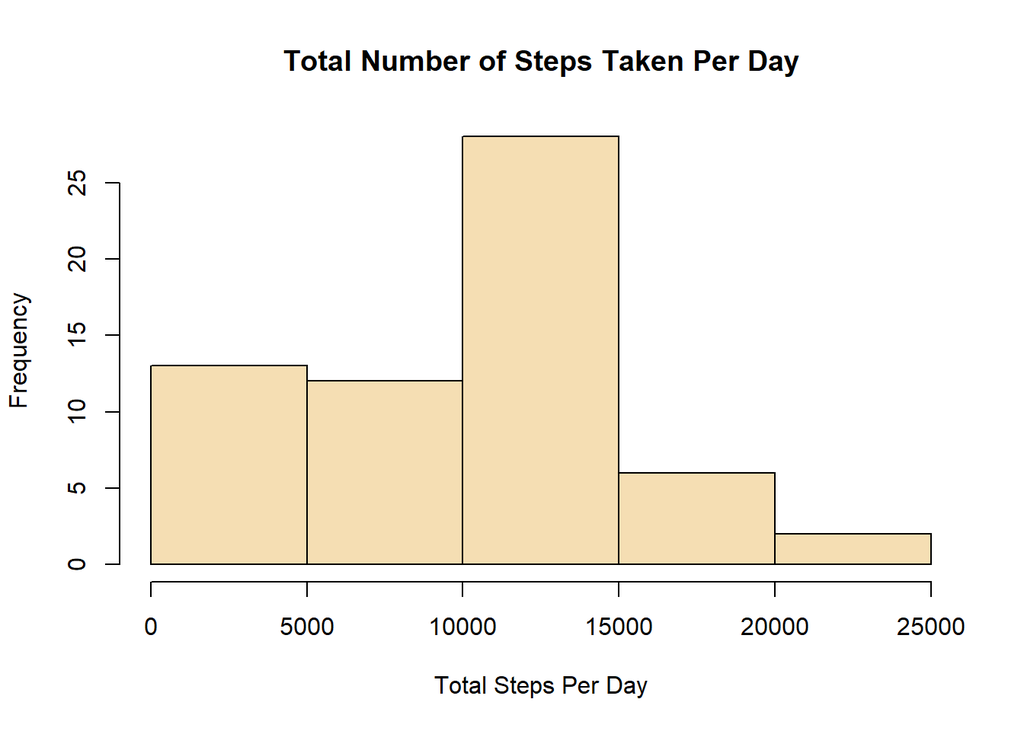

```r
hist(dailytotal$steps, col = "wheat", main = "Total Number of Steps Taken Per Day", xlab = "Total Steps Per Day")
```

```r
dailystat <- summarize(day, mean = mean(steps, na.rm=TRUE), median = median(steps, na.rm=TRUE))
print(dailystat)
```

```
## # A tibble: 61 x 3
##    date          mean median
##    <chr>        <dbl>  <dbl>
##  1 2012-10-01 NaN         NA
##  2 2012-10-02   0.438      0
##  3 2012-10-03  39.4        0
##  4 2012-10-04  42.1        0
##  5 2012-10-05  46.2        0
##  6 2012-10-06  53.5        0
##  7 2012-10-07  38.2        0
##  8 2012-10-08 NaN         NA
##  9 2012-10-09  44.5        0
## 10 2012-10-10  34.4        0
## # ... with 51 more rows
```

### Average Daily Pattern

**1. The code below creates a time series plot of the 5-minute interval and the average number of steps taken, averaged across all days.**

```r
interval <- group_by(data, interval)
average <- summarize(interval, steps = mean(steps, na.rm=TRUE))
```

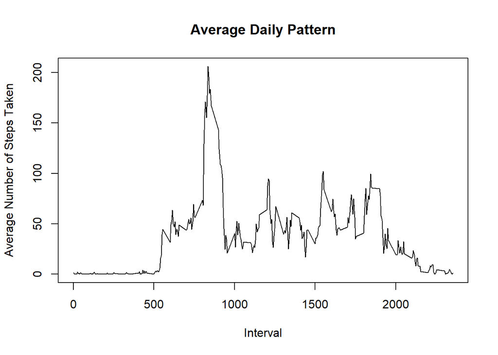

```r
plot(average$interval, average$steps, xlab = "Interval", ylab = "Average Number of Steps Taken", main = "Average Daily Pattern", type = "l")
```

**2. The maximum average number of steps across all days occurs on which 5-minute interval?**

```r
maxsteps <- average[which.max(average$steps),]
print(maxsteps)
```

```
## # A tibble: 1 x 2
##   interval steps
##      <int> <dbl>
## 1      835  206.
```

### Imputing Missing Values

**1. Shown below is the code that calculates and reports the total number of missing values in the data set.**

```r
nrow(data[data$steps == "NA",])
```

```
## [1] 2304
```

**2. This code fills in all of the missing values in the dataset with the mean for each corresponding 5-minute interval.**

```r
newdata <- data
for(i in 1:nrow(newdata)){
  if(is.na(data$steps[i])){
    newdata$steps[i] <- average$steps[match(data$interval[i], average$interval)]
  }
}
```

**3. This line shows the new dataset with the missing data filled in.**

```r
head(newdata)
```

```
##       steps       date interval
## 1 1.7169811 2012-10-01        0
## 2 0.3396226 2012-10-01        5
## 3 0.1320755 2012-10-01       10
## 4 0.1509434 2012-10-01       15
## 5 0.0754717 2012-10-01       20
## 6 2.0943396 2012-10-01       25
```

```r
newday <- group_by(newdata, date)
newdailytotal <- summarize(newday, steps = sum(steps, na.rm=TRUE))
print(newdailytotal)
```

```
## # A tibble: 61 x 2
##    date        steps
##    <chr>       <dbl>
##  1 2012-10-01 10766.
##  2 2012-10-02   126
##  3 2012-10-03 11352
##  4 2012-10-04 12116
##  5 2012-10-05 13294
##  6 2012-10-06 15420
##  7 2012-10-07 11015
##  8 2012-10-08 10766.
##  9 2012-10-09 12811
## 10 2012-10-10  9900
## # ... with 51 more rows
```

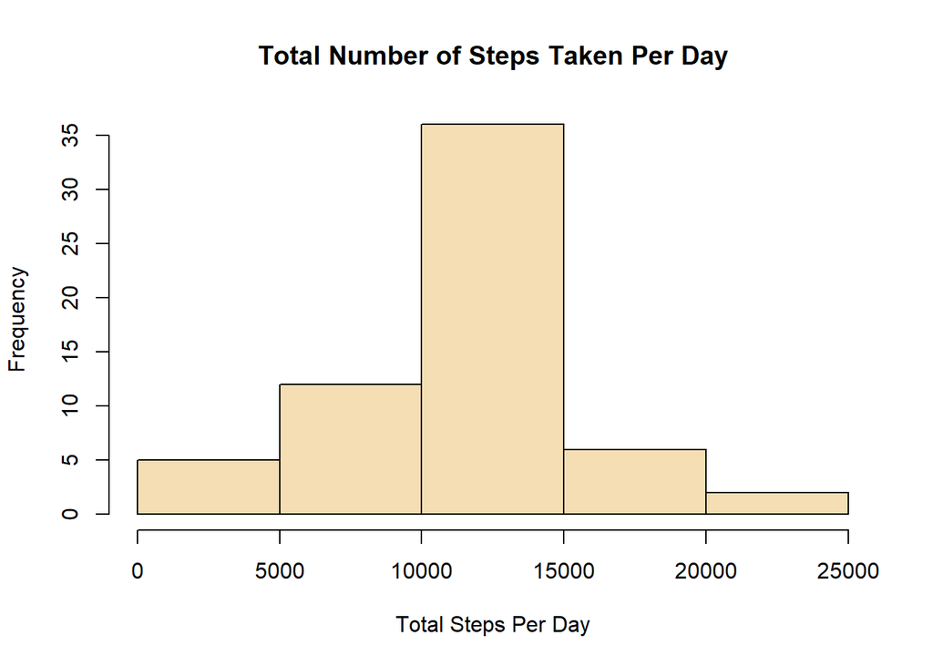

```r
hist(newdailytotal$steps, col = "wheat", main = "Total Number of Steps Taken Per Day", xlab = "Total Steps Per Day")
```

```r
newdailystat <- summarize(newday, mean = mean(steps, na.rm=TRUE), median = median(steps, na.rm=TRUE))
print(newdailystat)
```

```
## # A tibble: 61 x 3
##    date         mean median
##    <chr>       <dbl>  <dbl>
##  1 2012-10-01 37.4     34.1
##  2 2012-10-02  0.438    0
##  3 2012-10-03 39.4      0
##  4 2012-10-04 42.1      0
##  5 2012-10-05 46.2      0
##  6 2012-10-06 53.5      0
##  7 2012-10-07 38.2      0
##  8 2012-10-08 37.4     34.1
##  9 2012-10-09 44.5      0
## 10 2012-10-10 34.4      0
## # ... with 51 more rows
```

It can be seen that the original histogram differs from the new histogram in terms of shape, where the latter resembles a more bell-shaped curve. Imputing missing data has increased the estimates of the total daily number of steps as well.

### Differences in Activity Patterns Between Weekdays and Weekends

**1. This part creates a new factor variable in the dataset with two levels - “weekday” and “weekend” indicating whether a given data is on a weekday or weekend day.**

```r
newdata$day <- ifelse(weekdays(as.Date(data$date))%in% c("Monday", "Tuesday", "Wednesday", "Thursday", "Friday"), "weekday", "weekend")
head(newdata)
```

```
##       steps       date interval     day
## 1 1.7169811 2012-10-01        0 weekday
## 2 0.3396226 2012-10-01        5 weekday
## 3 0.1320755 2012-10-01       10 weekday
## 4 0.1509434 2012-10-01       15 weekday
## 5 0.0754717 2012-10-01       20 weekday
## 6 2.0943396 2012-10-01       25 weekday
```

**2. The code below shows the creation of a panel plot containing a time series plot of the 5-minute interval and the average number of steps taken, averaged across all weekday days or weekend days.**

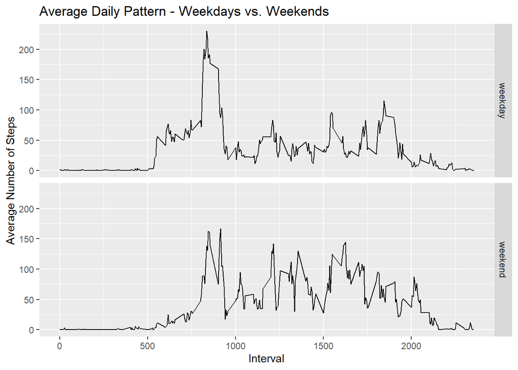

```r
newaverage <- aggregate(steps~interval+day, newdata, mean)
ggplot(newaverage, aes(interval, steps)) + geom_line() + facet_grid(day ~ .) + labs(x ="Interval") + labs(y = "Average Number of Steps") + labs(title = "Average Daily Pattern - Weekdays vs. Weekends")
```